# RNA-seq differential expression analysis workflow

UEB

November 2021

This material has been created using the following sources:

- https://combine-australia.github.io/RNAseq-R/
- https://www.bioconductor.org/packages/release/workflows/vignettes/RNAseq123/inst/doc/limmaWorkflow.html

# 1 Before starting

## 1.1 Set directories

Create a directory for the practicum named “PracticumRNAseq” and a subfolder named “data” where you will place all the files needed for the analysis.

Set the working directory to the folder `PracticumRNAseq`.

## 1.2 Installation of packages

Install Bioconductor (https://www.bioconductor.org/install/):

```r
if (!requireNamespace("BiocManager", quietly = TRUE))
    install.packages("BiocManager")
BiocManager::install(version = "3.12")
```

Packages from Bioconductor can be installed with `BiocManager::install("pkg")` function, where “pkg” is the package to be installed.

The following packages will be used in this workflow:

- `Rsubread` package: provides tools for alignment and quantification of reads
- `edgeR` package: provides tools for pre-pocessing and visualizing counts data
- `limma` package: provides tools for differential expression analysis
- `pheatmap` package: provides tools for plotting heatmaps

```r
BiocManager::install("Rsubread")
BiocManager::install("edgeR")
BiocManager::install("limma")
BiocManager::install("pheatmap")
```

We can now load the packages

```r
library(Rsubread)
library(edgeR)
library(limma)
library(pheatmap)
```

# 2 Data for the analysis

## 2.1 Mouse mammary gland dataset

The data for this tutorial comes from a Nature Cell Biology paper, [*EGF-mediated induction of Mcl-1 at the switch to lactation is essential for alveolar cell survival*](http://www.ncbi.nlm.nih.gov/pubmed/25730472) (Fu et al 2015). Both the raw data (sequence reads) and processed data (counts) are available for downloaded from Gene Expression Omnibus database (GEO) under accession number GSE60450.

This study examines the expression profiles of basal stem-cell enriched cells (B) and committed luminal cells (L) in the mammary gland of virgin, pregnant and lactating mice. Six groups are present, with one for each combination of cell type and mouse status. Each group contains two biological replicates.

## 2.2 Files

The following files are provided, which can be downloaded into the `data` directory:

- *SampleInfo.txt*: contains sample information
- 4 files *.bam*: contain the alignment results for 4 of the samples (demo dataset)
- *GSE60450_Lactation-GenewiseCounts.txt*: contains the counts matrix of the whole dataset

## 2.3 Reading in Sample information

The *SampleInfo.txt* file contains basic information about the samples:

```r
# Read the sample information into R
sampleinfo <- read.delim("./data/SampleInfo.txt")
sampleinfo
```

```
##                             FileName SampleName CellType   Status
## 1  MCL1.DG_BC2CTUACXX_ACTTGA_L002_R1    MCL1.DG  luminal   virgin
## 2  MCL1.DH_BC2CTUACXX_CAGATC_L002_R1    MCL1.DH    basal   virgin
## 3  MCL1.DI_BC2CTUACXX_ACAGTG_L002_R1    MCL1.DI    basal pregnant
## 4  MCL1.DJ_BC2CTUACXX_CGATGT_L002_R1    MCL1.DJ    basal pregnant
## 5  MCL1.DK_BC2CTUACXX_TTAGGC_L002_R1    MCL1.DK    basal  lactate
## 6  MCL1.DL_BC2CTUACXX_ATCACG_L002_R1    MCL1.DL    basal  lactate
## 7  MCL1.LA_BC2CTUACXX_GATCAG_L001_R1    MCL1.LA    basal   virgin
## 8  MCL1.LB_BC2CTUACXX_TGACCA_L001_R1    MCL1.LB  luminal   virgin
## 9  MCL1.LC_BC2CTUACXX_GCCAAT_L001_R1    MCL1.LC  luminal pregnant
## 10 MCL1.LD_BC2CTUACXX_GGCTAC_L001_R1    MCL1.LD  luminal pregnant
## 11 MCL1.LE_BC2CTUACXX_TAGCTT_L001_R1    MCL1.LE  luminal  lactate
## 12 MCL1.LF_BC2CTUACXX_CTTGTA_L001_R1    MCL1.LF  luminal  lactate
##            SRAFileName
## 1  SRR1552450.fastq.gz
## 2  SRR1552451.fastq.gz
## 3  SRR1552452.fastq.gz
## 4  SRR1552453.fastq.gz
## 5  SRR1552454.fastq.gz
## 6  SRR1552455.fastq.gz
## 7  SRR1552444.fastq.gz
## 8  SRR1552445.fastq.gz
## 9  SRR1552446.fastq.gz
## 10 SRR1552447.fastq.gz
## 11 SRR1552448.fastq.gz
## 12 SRR1552449.fastq.gz
```

# 3 Quantification of aligned reads: obtaining the counts matrix (demo)

The alignment produces a set of BAM files, where each file contains the read alignments for each library. In the BAM file, there is a chromosomal location for every read that mapped to that position. For demonstration purposes, we’re only using a subset of 1000 reads per sample, aligned to the chromosome 1 of the mouse genome.

We will use the `Rsubread` package, which provides functions for read mapping and quantification.

```r
library(Rsubread)
```

```r
bam.files <- list.files(path = "./data", pattern = ".BAM$", full.names = TRUE)
bam.files
```

```
## [1] "./data/SRR1552444.fastq.gz.subread.BAM"
## [2] "./data/SRR1552445.fastq.gz.subread.BAM"
## [3] "./data/SRR1552446.fastq.gz.subread.BAM"
## [4] "./data/SRR1552447.fastq.gz.subread.BAM"
```

We can see the proportion of reads that were mapped to chromosome 1:

```r
props <- propmapped(files=bam.files)[,1:2]
props
```

```
##                                 NumTotal NumMapped
## SRR1552444.fastq.gz.subread.BAM     1000       145
## SRR1552445.fastq.gz.subread.BAM     1000       136
## SRR1552446.fastq.gz.subread.BAM     1000       120
## SRR1552447.fastq.gz.subread.BAM     1000       113
```

The mapped reads can be counted across mouse genes by using the featureCounts function. featureCounts contains built-in annotation for mouse (mm9, mm10) and human (hg19) genome assemblies (NCBI refseq annotation).

The code below uses the exon intervals defined in the NCBI refseq annotation of the mm10 genome. Reads that map to exons of genes are added together to obtain the count for each gene, with some care taken with reads that span exon-exon boundaries. We will use the default settings in `featureCounts()` function.

Check the default settings using the help:

```r
?featureCounts
```

Are multimapping reads counted? If a read overlaps two exons, is it counted twice?

`featureCounts` takes all the BAM files as input, and outputs an object which includes the count matrix. Each sample is a separate column, each row is a gene.

```r
fc <- featureCounts(bam.files, annot.inbuilt="mm10")
```

```
## NCBI RefSeq annotation for mm10 (build 38.1) is used.
##
##         ==========     _____ _    _ ____  _____  ______          _____
##         =====         / ____| |  | |  _ \|  __ \|  ____|   /\   |  __ \
##           =====      | (___ | |  | | |_) | |__) | |__     /  \  | |  | |
##             ====      \___ \| |  | |  _ <|  _  /|  __|   / /\ \ | |  | |
##               ====    ____) | |__| | |_) | | \ \| |____ / ____ \| |__| |
##         ==========   |_____/ \____/|____/|_|  \_\______/_/    \_\_____/
##        Rsubread 2.6.4
##
## //========================== featureCounts setting ===========================\\
## ||                                                                            ||
## ||             Input files : 4 BAM files                                      ||
## ||                                                                            ||
## ||                           SRR1552444.fastq.gz.subread.BAM                  ||
## ||                           SRR1552445.fastq.gz.subread.BAM                  ||
## ||                           SRR1552446.fastq.gz.subread.BAM                  ||
## ||                           SRR1552447.fastq.gz.subread.BAM                  ||
## ||                                                                            ||
## ||              Paired-end : no                                               ||
## ||        Count read pairs : no                                               ||
## ||              Annotation : inbuilt (mm10)                                   ||
## ||      Dir for temp files : .                                                ||
## ||                 Threads : 1                                                ||
## ||                   Level : meta-feature level                               ||
## ||      Multimapping reads : counted                                          ||
## || Multi-overlapping reads : not counted                                      ||
## ||   Min overlapping bases : 1                                                ||
## ||                                                                            ||
## \\============================================================================//
##
## //================================= Running ==================================\\
## ||                                                                            ||
## || Load annotation file mm10_RefSeq_exon.txt ...                              ||
## ||    Features : 222996                                                       ||
## ||    Meta-features : 27179                                                   ||
## ||    Chromosomes/contigs : 43                                                ||
## ||                                                                            ||
## || Process BAM file SRR1552444.fastq.gz.subread.BAM...                        ||
## ||    Single-end reads are included.                                          ||
```

[output cut: 11 more lines]

```
## ||    Single-end reads are included.                                          ||
## ||    Total alignments : 1000                                                 ||
## ||    Successfully assigned alignments : 34 (3.4%)                            ||
## ||    Running time : 0.00 minutes                                             ||
## ||                                                                            ||
## || Process BAM file SRR1552447.fastq.gz.subread.BAM...                        ||
## ||    Single-end reads are included.                                          ||
## ||    Total alignments : 1000                                                 ||
## ||    Successfully assigned alignments : 34 (3.4%)                            ||
## ||    Running time : 0.00 minutes                                             ||
## ||                                                                            ||
## || Write the final count table.                                               ||
## || Write the read assignment summary.                                         ||
## ||                                                                            ||
## \\============================================================================//
```

```r
# See what slots (fields) are stored in fc
names(fc)
```

```
## [1] "counts"     "annotation" "targets"    "stat"
```

The statistics of the read mapping can be seen with fc$stats. This reports the numbers of unassigned reads and the reasons why they are not assigned (eg. ambiguity, multi-mapping,…), in addition to the number of successfully assigned reads for each library. (We know the real reason why the majority of the reads aren’t mapping - they’re not from chr 1!)

```r
## Take a look at the featurecounts stats
fc$stat
```

```
##                           Status SRR1552444.fastq.gz.subread.BAM
## 1                       Assigned                              50
## 2            Unassigned_Unmapped                             855
## 3           Unassigned_Read_Type                               0
## 4           Unassigned_Singleton                               0
## 5      Unassigned_MappingQuality                               0
## 6             Unassigned_Chimera                               0
## 7      Unassigned_FragmentLength                               0
## 8           Unassigned_Duplicate                               0
## 9        Unassigned_MultiMapping                               0
## 10          Unassigned_Secondary                               0
## 11           Unassigned_NonSplit                               0
## 12         Unassigned_NoFeatures                              95
## 13 Unassigned_Overlapping_Length                               0
## 14          Unassigned_Ambiguity                               0
```

[output cut: 30 more lines]

Annotations used for summarizing reads to gene-level:

```r
head(fc$annotation)
```

```
##      GeneID                           Chr
## 1    497097                chr1;chr1;chr1
## 2 100503874                     chr1;chr1
## 3 100038431                          chr1
## 4     19888 chr1;chr1;chr1;chr1;chr1;chr1
## 5     20671      chr1;chr1;chr1;chr1;chr1
## 6     27395      chr1;chr1;chr1;chr1;chr1
##                                             Start
## 1                         3214482;3421702;3670552
## 2                                 3647309;3658847
## 3                                         3680155
## 4 4290846;4343507;4351910;4352202;4360200;4409170
## 5         4490928;4493100;4493772;4495136;4496291
## 6         4773198;4777525;4782568;4783951;4785573
##                                               End      Strand Length
## 1                         3216968;3421901;3671498       -;-;-   3634
## 2                                 3650509;3658904         -;-   3259
## 3                                         3681788           +   1634
## 4 4293012;4350091;4352081;4352837;4360314;4409241 -;-;-;-;-;-   9747
## 5         4492668;4493466;4493863;4495942;4496413   -;-;-;-;-   3130
## 6         4776801;4777648;4782733;4784105;4785726   -;-;-;-;-   4203
```

The counts for the samples are stored in fc$counts. Take a look at that.

```r
## Take a look at the dimensions to see the number of genes
dim(fc$counts)
```

```
## [1] 27179     4
```

```r
## Take a look at the first 6 lines
head(fc$counts)
```

```
##           SRR1552444.fastq.gz.subread.BAM SRR1552445.fastq.gz.subread.BAM
## 497097                                  0                               0
## 100503874                               0                               0
## 100038431                               0                               0
## 19888                                   0                               0
## 20671                                   0                               0
## 27395                                   0                               0
##           SRR1552446.fastq.gz.subread.BAM SRR1552447.fastq.gz.subread.BAM
## 497097                                  0                               0
## 100503874                               0                               0
## 100038431                               0                               0
## 19888                                   0                               0
## 20671                                   0                               0
## 27395                                   0                               0
```

```r
counts_chr1 <- fc$counts
```

Save the counts matrix into a text file.

```r
write.table(counts_chr1, "counts_chr1.txt")
```

**Challenge**

Redo the counting over the exons, rather than the genes (specify `useMetaFeatures = FALSE`), and call the `featureCounts` object `fc.exon`. Check the dimension of the counts matrix. Any differences?

# 4 Import the original counts matrix

The count matrix for the whole dataset can be downloaded from the [GEO website](http://www.ncbi.nlm.nih.gov/geo/query/acc.cgi?acc=GSE60450) and is contained in file *GSE60450_Lactation-GenewiseCounts.txt*.

Let’s take a look at the data.

```r
# Read the data into R
seqdata <- read.delim("./data/GSE60450_Lactation-GenewiseCounts.txt", stringsAsFactors = FALSE)
dim(seqdata)
```

```
## [1] 27179    14
```

```r
head(seqdata)
```

```
##   EntrezGeneID Length MCL1.DG_BC2CTUACXX_ACTTGA_L002_R1
## 1       497097   3634                               438
## 2    100503874   3259                                 1
## 3    100038431   1634                                 0
## 4        19888   9747                                 1
## 5        20671   3130                               106
## 6        27395   4203                               309
##   MCL1.DH_BC2CTUACXX_CAGATC_L002_R1 MCL1.DI_BC2CTUACXX_ACAGTG_L002_R1
## 1                               300                                65
## 2                                 0                                 1
## 3                                 0                                 0
## 4                                 1                                 0
## 5                               182                                82
## 6                               234                               337
##   MCL1.DJ_BC2CTUACXX_CGATGT_L002_R1 MCL1.DK_BC2CTUACXX_TTAGGC_L002_R1
```

[output cut: 34 more lines]

The `seqdata` object contains information about genes (one gene per row), the first column has the Entrez gene id, the second has the gene length and the remaining columns contain information about the number of reads aligning to the gene in each experimental sample.

## 4.1 Format the data

We will be manipulating and reformating the counts matrix into a suitable format for downstream analysis. We need to make a new matrix containing only the counts, but we can store the gene identifiers (the `EntrezGeneID` column) as rownames.

Let’s create a new data object, `countdata`, that contains only the counts for the 12 samples.

```r
# Remove first two columns from seqdata
countdata <- seqdata[,-(1:2)]
# Store EntrezGeneID as rownames
rownames(countdata) <- seqdata$EntrezGeneID
```

Now take a look at the column names

```r
colnames(countdata)
```

```
##  [1] "MCL1.DG_BC2CTUACXX_ACTTGA_L002_R1" "MCL1.DH_BC2CTUACXX_CAGATC_L002_R1"
##  [3] "MCL1.DI_BC2CTUACXX_ACAGTG_L002_R1" "MCL1.DJ_BC2CTUACXX_CGATGT_L002_R1"
##  [5] "MCL1.DK_BC2CTUACXX_TTAGGC_L002_R1" "MCL1.DL_BC2CTUACXX_ATCACG_L002_R1"
##  [7] "MCL1.LA_BC2CTUACXX_GATCAG_L001_R1" "MCL1.LB_BC2CTUACXX_TGACCA_L001_R1"
##  [9] "MCL1.LC_BC2CTUACXX_GCCAAT_L001_R1" "MCL1.LD_BC2CTUACXX_GGCTAC_L001_R1"
## [11] "MCL1.LE_BC2CTUACXX_TAGCTT_L001_R1" "MCL1.LF_BC2CTUACXX_CTTGTA_L001_R1"
```

These are the file names for each sample, which are pretty long. We will rename the columns with the SampleNames stored in the `sampleinfo` dataframe. We first need to verify they are in the same order (this is very important!):

```r
all.equal(colnames(countdata), sampleinfo$FileName)
```

```
## [1] TRUE
```

Then we can assign the new names:

```r
colnames(countdata) <- sampleinfo$SampleName
head(countdata)
```

```
##           MCL1.DG MCL1.DH MCL1.DI MCL1.DJ MCL1.DK MCL1.DL MCL1.LA MCL1.LB
## 497097        438     300      65     237     354     287       0       0
## 100503874       1       0       1       1       0       4       0       0
## 100038431       0       0       0       0       0       0       0       0
## 19888           1       1       0       0       0       0      10       3
## 20671         106     182      82     105      43      82      16      25
## 27395         309     234     337     300     290     270     560     464
##           MCL1.LC MCL1.LD MCL1.LE MCL1.LF
## 497097          0       0       0       0
## 100503874       0       0       0       0
## 100038431       0       0       0       0
## 19888          10       2       0       0
## 20671          18       8       3      10
## 27395         489     328     307     342
```

# 5 Data pre-processing and exploratory analysis

## 5.1 Filtering to remove lowly expressed genes

Genes with very low counts across all libraries provide little evidence for differential expression and they interfere with some of the statistical approximations that are used later in the pipeline. They also add to the multiple testing burden when estimating false discovery rates, reducing power to detect differentially expressed genes. These genes should be filtered out prior to further analysis.

Filtering is performed on CPMs rather than filtering on the counts directly, as the latter does not account for differences in library sizes between samples. Here raw counts are normalised for the different sequencing depths (library sizes) for each sample and converted to counts-per-million (CPM) values using the `cpm()` function in `edgeR`. In this dataset, we choose to retain genes if they are expressed at a CPM above 0.5 in at least two samples.

```r
colSums(countdata)
```

```
##  MCL1.DG  MCL1.DH  MCL1.DI  MCL1.DJ  MCL1.DK  MCL1.DL  MCL1.LA  MCL1.LB
## 23227641 21777891 24100765 22665371 21529331 20015386 20392113 21708152
##  MCL1.LC  MCL1.LD  MCL1.LE  MCL1.LF
## 22241607 21988240 24723827 24657293
```

```r
# Obtain CPMs
counts.CPM <- cpm(countdata)
# Have a look at the output
head(counts.CPM)
```

```
##               MCL1.DG     MCL1.DH     MCL1.DI     MCL1.DJ   MCL1.DK    MCL1.DL
## 497097    18.85684388 13.77543859  2.69700983 10.45648006 16.442685 14.3389690
## 100503874  0.04305215  0.00000000  0.04149246  0.04412017  0.000000  0.1998463
## 100038431  0.00000000  0.00000000  0.00000000  0.00000000  0.000000  0.0000000
## 19888      0.04305215  0.04591813  0.00000000  0.00000000  0.000000  0.0000000
## 20671      4.56352843  8.35709941  3.40238163  4.63261775  1.997275  4.0968483
## 27395     13.30311589 10.74484210 13.98295863 13.23605071 13.469996 13.4896224
##              MCL1.LA    MCL1.LB    MCL1.LC     MCL1.LD    MCL1.LE    MCL1.LF
## 497097     0.0000000  0.0000000  0.0000000  0.00000000  0.0000000  0.0000000
## 100503874  0.0000000  0.0000000  0.0000000  0.00000000  0.0000000  0.0000000
## 100038431  0.0000000  0.0000000  0.0000000  0.00000000  0.0000000  0.0000000
## 19888      0.4903857  0.1381969  0.4496078  0.09095771  0.0000000  0.0000000
## 20671      0.7846171  1.1516411  0.8092940  0.36383085  0.1213404  0.4055595
## 27395     27.4615975 21.3744588 21.9858214 14.91706476 12.4171715 13.8701357
```

```r
# Which values in myCPM are greater than 0.5?
thresh <- counts.CPM > 0.5
# This produces a logical matrix with TRUEs and FALSEs
head(thresh)
```

```
##           MCL1.DG MCL1.DH MCL1.DI MCL1.DJ MCL1.DK MCL1.DL MCL1.LA MCL1.LB
## 497097       TRUE    TRUE    TRUE    TRUE    TRUE    TRUE   FALSE   FALSE
## 100503874   FALSE   FALSE   FALSE   FALSE   FALSE   FALSE   FALSE   FALSE
## 100038431   FALSE   FALSE   FALSE   FALSE   FALSE   FALSE   FALSE   FALSE
## 19888       FALSE   FALSE   FALSE   FALSE   FALSE   FALSE   FALSE   FALSE
## 20671        TRUE    TRUE    TRUE    TRUE    TRUE    TRUE    TRUE    TRUE
## 27395        TRUE    TRUE    TRUE    TRUE    TRUE    TRUE    TRUE    TRUE
##           MCL1.LC MCL1.LD MCL1.LE MCL1.LF
## 497097      FALSE   FALSE   FALSE   FALSE
## 100503874   FALSE   FALSE   FALSE   FALSE
## 100038431   FALSE   FALSE   FALSE   FALSE
## 19888       FALSE   FALSE   FALSE   FALSE
## 20671        TRUE   FALSE   FALSE   FALSE
## 27395        TRUE    TRUE    TRUE    TRUE
```

```r
# we would like to keep genes that have at least 2 TRUES in each row of thresh
keep <- rowSums(thresh) >= 2
# Subset the rows of countdata to keep the more highly expressed genes
counts.keep <- countdata[keep,]
dim(countdata)
```

```
## [1] 27179    12
```

```r
dim(counts.keep)
```

```
## [1] 15804    12
```

## 5.2 Convert counts to DGEList object

Next we’ll create a `DGEList` object. This is an object used by *edgeR* to store count data. It has a number of slots for storing various parameters about the data.

```r
dgeObj <- DGEList(counts.keep)
# have a look at dgeObj
dgeObj
```

```
## An object of class "DGEList"
## $counts
##        MCL1.DG MCL1.DH MCL1.DI MCL1.DJ MCL1.DK MCL1.DL MCL1.LA MCL1.LB MCL1.LC
## 497097     438     300      65     237     354     287       0       0       0
## 20671      106     182      82     105      43      82      16      25      18
## 27395      309     234     337     300     290     270     560     464     489
## 18777      652     515     948     935     928     791     826     862     668
## 21399     1604    1495    1721    1317    1159    1066    1334    1258    1068
##        MCL1.LD MCL1.LE MCL1.LF
## 497097       0       0       0
## 20671        8       3      10
## 27395      328     307     342
## 18777      646     544     581
## 21399      926     508     500
## 15799 more rows ...
##
## $samples
##         group lib.size norm.factors
## MCL1.DG     1 23218026            1
## MCL1.DH     1 21768136            1
## MCL1.DI     1 24091588            1
## MCL1.DJ     1 22656713            1
## MCL1.DK     1 21522033            1
## 7 more rows ...
```

```r
# See what slots are stored in dgeObj
names(dgeObj)
```

```
## [1] "counts"  "samples"
```

```r
# Library size information is stored in the samples slot
dgeObj$samples
```

```
##         group lib.size norm.factors
## MCL1.DG     1 23218026            1
## MCL1.DH     1 21768136            1
## MCL1.DI     1 24091588            1
## MCL1.DJ     1 22656713            1
## MCL1.DK     1 21522033            1
## MCL1.DL     1 20008326            1
## MCL1.LA     1 20384562            1
## MCL1.LB     1 21698793            1
## MCL1.LC     1 22235847            1
## MCL1.LD     1 21982745            1
## MCL1.LE     1 24719697            1
## MCL1.LF     1 24652963            1
```

Now that we have got rid of the lowly expressed genes and have our counts stored in a `DGEList` object, we can look at a few different plots to check that the data is good quality, and that the samples are as we would expect.

## 5.3 Boxplot of the unnormalized counts

Count data is not normally distributed, so if we want to examine the distributions of the raw counts we need to log the counts. Next we’ll use box plots to check the distribution of the read counts on the log2 scale. We can use the `cpm` function to get log2 counts per million, which are corrected for the different library sizes. The `cpm` function also adds a small offset to avoid taking log of zero.

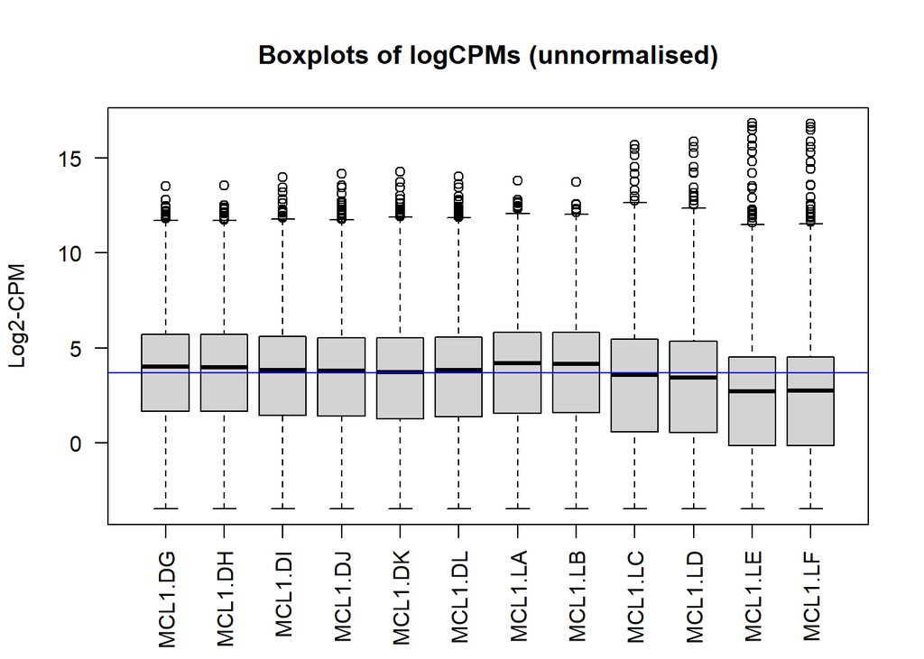

```r
# Get log2 counts per million
logcounts <- cpm(dgeObj,log=TRUE)
# Check distributions of samples using boxplots
boxplot(logcounts, ylab="Log2-CPM",las=2, xlab="", main="Boxplots of logCPMs (unnormalised)")
# Let's add a blue horizontal line that corresponds to the median logCPM
abline(h=median(logcounts), col="blue")
```

From the boxplots we see that overall the density distributions of raw log-intensities are not identical but still not very different. If a sample is really far above or below the blue horizontal line we may need to investigate that sample further.

## 5.4 Normalization

TMM normalization is performed to eliminate composition biases between libraries (Mark D. Robinson and Oshlack 2010). This generates a set of normalization factors, where the product of these factors and the library sizes defines the effective library size. The calcNormFactors function calculates the normalization factors between libraries.

```r
# Apply normalisation to DGEList object
dgeObj_norm <- calcNormFactors(dgeObj)
```

This will update the normalisation factors in the `DGEList` object (their default values are 1).

```r
dgeObj_norm
```

```
## An object of class "DGEList"
## $counts
##        MCL1.DG MCL1.DH MCL1.DI MCL1.DJ MCL1.DK MCL1.DL MCL1.LA MCL1.LB MCL1.LC
## 497097     438     300      65     237     354     287       0       0       0
## 20671      106     182      82     105      43      82      16      25      18
## 27395      309     234     337     300     290     270     560     464     489
## 18777      652     515     948     935     928     791     826     862     668
## 21399     1604    1495    1721    1317    1159    1066    1334    1258    1068
##        MCL1.LD MCL1.LE MCL1.LF
## 497097       0       0       0
## 20671        8       3      10
## 27395      328     307     342
## 18777      646     544     581
## 21399      926     508     500
## 15799 more rows ...
##
## $samples
##         group lib.size norm.factors
## MCL1.DG     1 23218026     1.236899
## MCL1.DH     1 21768136     1.213949
## MCL1.DI     1 24091588     1.125564
## MCL1.DJ     1 22656713     1.069826
## MCL1.DK     1 21522033     1.035921
## 7 more rows ...
```

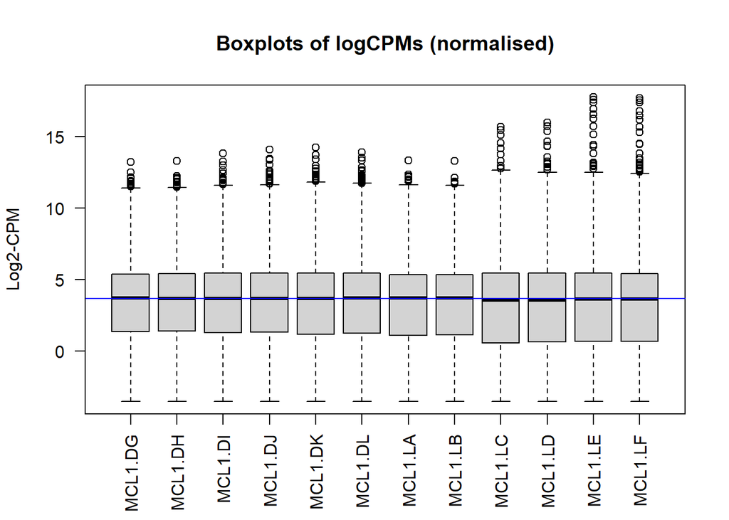

```r
# Get log2 counts per million
logcounts_norm <- cpm(dgeObj_norm,log=TRUE)
# Check distributions of samples using boxplots
boxplot(logcounts_norm, ylab="Log2-CPM",las=2, xlab="", main="Boxplots of logCPMs (normalised)")
# Let's add a blue horizontal line that corresponds to the median logCPM
abline(h=median(logcounts_norm), col="blue")
```

## 5.5 Hierarchical clustering of sample distances

To determine whether the different sample types can be separated in an unsupervised fashion (i.e., samples of different conditions are more dissimilar to each other than replicates within the same condition), hierarchical clustering can be used. Hierarchical clustering is typically based on pairwise comparisons of individual samples, which are grouped into “neighborhoods” of similar samples. The basis of hierarchical clustering is therefore a matrix of similarity metrics.

```r
sampleDists <- dist(t(logcounts_norm))
sampleDists
```

```
##           MCL1.DG   MCL1.DH   MCL1.DI   MCL1.DJ   MCL1.DK   MCL1.DL   MCL1.LA
## MCL1.DH  52.24654
## MCL1.DI 103.25705  98.25760
## MCL1.DJ 106.36290  99.30647  49.57083
## MCL1.DK 128.02782 128.52821  97.62799  84.98948
## MCL1.DL 125.86559 128.72828 103.11545  91.44977  46.73993
## MCL1.LA 218.22594 223.31947 232.50124 240.44598 256.64000 255.82355
## MCL1.LB 213.88210 217.09336 227.33020 234.98455 252.24239 251.40030  49.09938
## MCL1.LC 254.83729 258.89974 248.39509 260.65913 278.07560 278.52744 149.14326
## MCL1.LD 256.73737 260.11015 250.41689 260.28317 276.28758 276.87809 151.29250
## MCL1.LE 286.34996 290.39742 281.73902 291.20531 300.88662 300.60275 190.63664
## MCL1.LF 286.33309 290.93812 282.03286 291.46680 300.33939 299.46065 194.42521
##           MCL1.LB   MCL1.LC   MCL1.LD   MCL1.LE
## MCL1.DH
## MCL1.DI
## MCL1.DJ
## MCL1.DK
## MCL1.DL
## MCL1.LA
## MCL1.LB
## MCL1.LC 147.62266
## MCL1.LD 149.31188  59.52261
## MCL1.LE 190.51543 135.82290 136.62798
## MCL1.LF 193.93716 140.07902 141.13206  60.82715
```

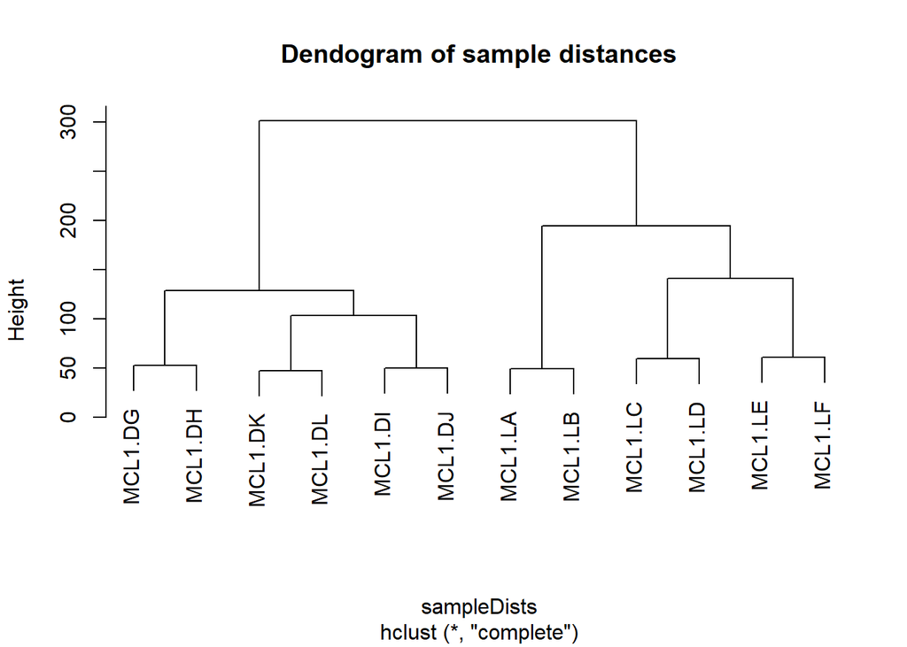

```r
plot(hclust(sampleDists),labels = colnames(logcounts_norm),main = "Dendogram of sample distances")
```

## 5.6 Principal Component Analysis (PCA)

A complementary approach to determine the main sources of variability in the data is principal components analysis (PCA). It is a typical example of dimensionality reduction approaches that aims to find groups of features (e.g., genes) that have something in common (e.g., certain patterns of expression across different samples), so that the information from thousands of features is captured and represented by a reduced number of groups.The result of PCA are principal components that represent the directions along which the variation in the original multi-dimensional data matrix is maximal. This way a few dimensions (components) can be used to represent the information from thousands of mRNAs. This allows us to, for example, visually represent the variation of the gene expression for different samples by using just the top two principal components (PCs) as coordinates in a simple xy plot (instead of plotting thousands of genes per sample).

We can use the `plotMDS` function to create the such a plot.

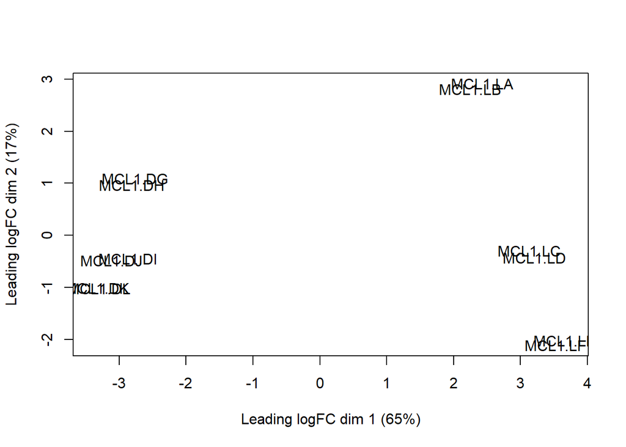

```r
plotMDS(logcounts_norm)
```

It is a bit difficult to see exactly what is going on with the default plot, although we do see samples grouping together in pairs. To make this plot more informative, we can colour the samples according to the grouping information (eg. Status):

```r
sampleinfo$Status <- factor (sampleinfo$Status)
col.status <- c("blue","red","dark green")[sampleinfo$Status]
data.frame(sampleinfo$Status,col.status)
```

```
##    sampleinfo.Status col.status
## 1             virgin dark green
## 2             virgin dark green
## 3           pregnant        red
## 4           pregnant        red
## 5            lactate       blue
## 6            lactate       blue
## 7             virgin dark green
## 8             virgin dark green
## 9           pregnant        red
## 10          pregnant        red
## 11           lactate       blue
## 12           lactate       blue
```

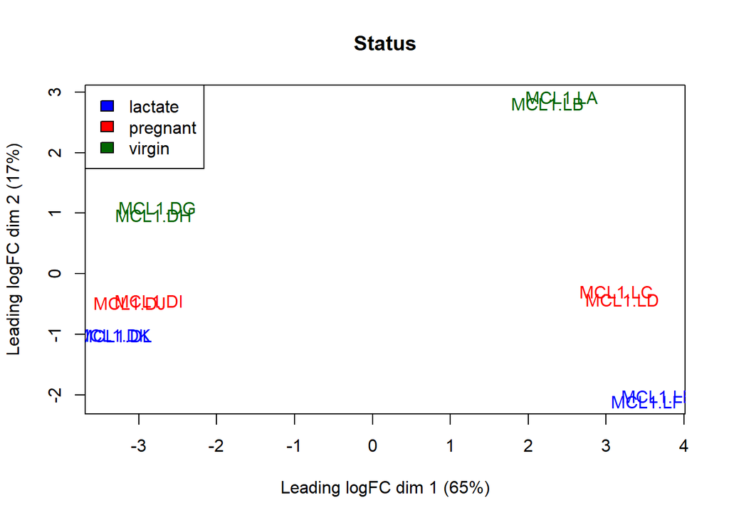

```r
plotMDS(logcounts_norm,col=col.status, main="Status")
# Let's add a legend to the plot so we know which colours correspond to which cell type
legend("topleft",fill=c("blue","red","dark green"),legend=levels(sampleinfo$Status))
```

**Challenge**

- What component separates samples by *Status*?
- Repeat the MDS plot coloring by CellType condition. Is there something strange going on with the samples?
- Identify the two samples that don’t appear to be in the right place.

Solution

```r
# Redo the MDS with cell type colouring
## Let's choose purple for basal and orange for luminal
sampleinfo$CellType <- factor(sampleinfo$CellType)
col.cell <- c("purple","orange")[sampleinfo$CellType]
data.frame(sampleinfo$CellType,col.cell)
```

```
##    sampleinfo.CellType col.cell
## 1              luminal   orange
## 2                basal   purple
## 3                basal   purple
## 4                basal   purple
## 5                basal   purple
## 6                basal   purple
## 7                basal   purple
## 8              luminal   orange
## 9              luminal   orange
## 10             luminal   orange
## 11             luminal   orange
## 12             luminal   orange
```

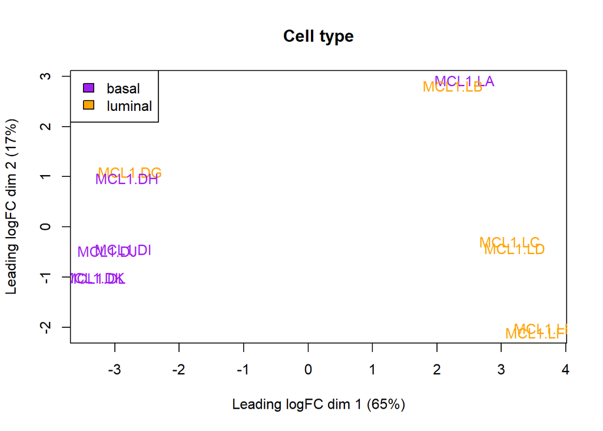

```r
plotMDS(logcounts_norm,col=col.cell, main="Cell type")
# Let's add a legend to the plot so we know which colours correspond to which cell type
legend("topleft",fill=c("purple","orange"),legend=levels(sampleinfo$CellType))
```

## 5.7 Correcting the sample info

Both the hierarchical clustering and MDS plots suggest that two samples may be mislabelled. We can correct now the sampleinfo file with this new information.

```r
sampleinfo$CellType[1] <- "basal"
sampleinfo$CellType[7] <- "luminal"
```

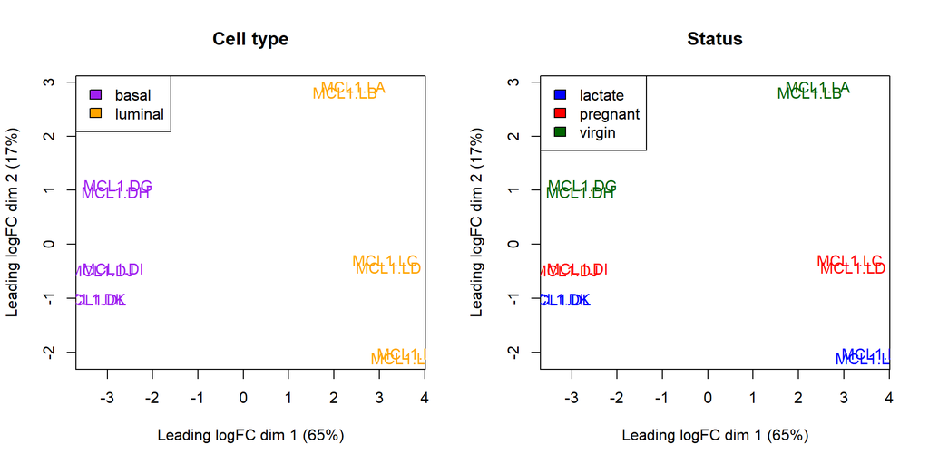

```r
# Redo the MDSplot with corrected information
par(mfrow=c(1,2))
col.cell <- c("purple","orange")[sampleinfo$CellType]
col.status <- c("blue","red","dark green")[sampleinfo$Status]

plotMDS(logcounts_norm,col=col.cell, main="Cell type")
legend("topleft",fill=c("purple","orange"),legend=levels(sampleinfo$CellType))

plotMDS(logcounts_norm,col=col.status, main="Status")
legend("topleft",fill=c("blue","red","dark green"),legend=levels(sampleinfo$Status))
```

# 6 Differential expression analysis with limma-voom

Now that we are happy that we have normalised the data and that the quality looks good, we can continue to testing for differentially expressed genes. There are a number of packages to analyse RNA-Seq data. The `limma package` (Ritchie et al. 2015) offers the `voom` function, which transforms the read counts into logCPMs while taking into account the mean-variance relationship in the data (Charity W. Law et al. 2014). After vooming, users can apply a linear model to the voom-transformed data to test for differentially expressed genes, with the assumption that the underlying data is normally distributed.

## 6.1 Creating a design matrix and contrasts

First we need to create a design matrix for the groups of interest that we want to test. In this analysis let’s assume that we will be testing differences in status in the different cell types separately. For example, we want to know which genes are differentially expressed between pregnant and lactating in basal cells only. We will code the `group` variable as a concatenation of cell type and status. Coding the cell type and status in this way allows us to be flexible in specifying which comparisons we are interested in.

Each column of the design matrix tells us which samples correspond to each group.

```r
group <- paste(sampleinfo$CellType, sampleinfo$Status, sep=".")
design <- model.matrix(~0+group)
colnames(design) <- gsub("group", "", colnames(design))
rownames(design) <- sampleinfo$SampleName
design
```

```
##         basal.lactate basal.pregnant basal.virgin luminal.lactate
## MCL1.DG             0              0            1               0
## MCL1.DH             0              0            1               0
## MCL1.DI             0              1            0               0
## MCL1.DJ             0              1            0               0
## MCL1.DK             1              0            0               0
## MCL1.DL             1              0            0               0
## MCL1.LA             0              0            0               0
## MCL1.LB             0              0            0               0
## MCL1.LC             0              0            0               0
## MCL1.LD             0              0            0               0
## MCL1.LE             0              0            0               1
## MCL1.LF             0              0            0               1
##         luminal.pregnant luminal.virgin
## MCL1.DG                0              0
## MCL1.DH                0              0
## MCL1.DI                0              0
## MCL1.DJ                0              0
## MCL1.DK                0              0
## MCL1.DL                0              0
## MCL1.LA                0              1
## MCL1.LB                0              1
## MCL1.LC                1              0
## MCL1.LD                1              0
## MCL1.LE                0              0
## MCL1.LF                0              0
## attr(,"assign")
## [1] 1 1 1 1 1 1
## attr(,"contrasts")
## attr(,"contrasts")$group
## [1] "contr.treatment"
```

Since we are interested in differences between groups, we need to specify which comparisons we want to test. The comparison of interest can be specified using the `makeContrasts` function. The contrast matrix tells limma which columns of the design matrix we are interested in testing our comparison.

Here, we are interested in knowing which genes are differentially expressed between the pregnant and lactating group in the basal cells. This is done by defining the null hypothesis as basal.pregnant - basal.lactate = 0 for each gene. Note that the group names must exactly match the column names of the design matrix.

```r
cont.matrix <- makeContrasts(B.PregVsLac=basal.pregnant - basal.lactate, levels=design)
cont.matrix
```

```
##                   Contrasts
## Levels             B.PregVsLac
##   basal.lactate             -1
##   basal.pregnant             1
##   basal.virgin               0
##   luminal.lactate            0
##   luminal.pregnant           0
##   luminal.virgin             0
```

## 6.2 Voom-transformation of the data

```r
voomObj <- voom(dgeObj_norm,design)
voomObj
```

```
## An object of class "EList"
## $targets
##         group lib.size norm.factors
## MCL1.DG     1 28718360     1.236899
## MCL1.DH     1 26425396     1.213949
## MCL1.DI     1 27116624     1.125564
## MCL1.DJ     1 24238743     1.069826
## MCL1.DK     1 22295130     1.035921
## 7 more rows ...
##
## $E
##         MCL1.DG  MCL1.DH  MCL1.DI  MCL1.DJ   MCL1.DK  MCL1.DL    MCL1.LA
## 497097 3.932532 3.507368 1.272317 3.292541 3.9909851 3.724252 -5.8019424
## 20671  1.890808 2.787899 1.605217 2.121856 0.9642868 1.923156 -0.7575483
## 27395  3.429894 3.149591 3.637638 3.631978 3.7037376 3.636318  4.3286281
## 18777  4.505933 4.285975 5.128398 5.270351 5.3801014 5.185279  4.8889286
## 21399  5.804007 5.822559 5.988345 5.764344 5.7006304 5.615502  5.5801412
##           MCL1.LB    MCL1.LC   MCL1.LD   MCL1.LE    MCL1.LF
## 497097 -5.8887821 -5.4816421 -5.343143 -4.709206 -4.7226146
## 20671  -0.2163568 -0.2721888 -1.255680 -1.901851 -0.3302972
## 27395   3.9707527  4.4535229  4.016606  4.555237  4.6973455
## 18777   4.8635986  4.9031416  4.993363  5.379583  5.4610208
## 21399   5.4087074  5.5797290  5.512504  5.280898  5.2446116
## 15799 more rows ...
##
## $weights
##          [,1]     [,2]     [,3]     [,4]     [,5]     [,6]       [,7]
## [1,] 42.85032 40.59638 19.78119 18.11020 38.62541 37.98661  0.7907909
## [2,] 21.34610 19.99539 15.74020 14.40027 10.70068 10.49511  4.5401043
## [3,] 35.05544 33.04583 39.72941 36.82081 35.31518 34.70612 50.4586968
## [4,] 56.26175 53.86441 69.16366 66.65108 66.03797 65.46069 64.6692219
## [5,] 76.92857 75.98600 76.79528 75.45282 71.62644 71.16558 73.5980084
##            [,8]       [,9]      [,10]      [,11]      [,12]
## [1,]  0.7907909  0.7907909  0.7907909  0.7907909  0.7907909
## [2,]  4.7399033  3.4277768  3.2224692  2.1314506  2.1428929
## [3,] 52.1833006 45.7806579 43.1302387 38.6112610 38.8559918
## [4,] 66.0984998 60.0161723 57.3174922 54.0693981 54.3410792
## [5,] 74.5613544 70.1642210 68.1238307 50.8570652 51.1210163
## 15799 more rows ...
##
## $design
##         basal.lactate basal.pregnant basal.virgin luminal.lactate
## MCL1.DG             0              0            1               0
## MCL1.DH             0              0            1               0
## MCL1.DI             0              1            0               0
## MCL1.DJ             0              1            0               0
## MCL1.DK             1              0            0               0
##         luminal.pregnant luminal.virgin
## MCL1.DG                0              0
## MCL1.DH                0              0
## MCL1.DI                0              0
## MCL1.DJ                0              0
## MCL1.DK                0              0
## 7 more rows ...
```

## 6.3 Testing for differential expression

Now that we have the voom transformed data we can use `limma` to test for differential expression. First we fit a linear model for each gene using the `lmFit` function in `limma` package. `lmFit` needs the voom object and the design matrix that we have already specified, which is stored within the voom object.

```r
# Fit the linear model
fit <- lmFit(voomObj)
```

Now we can apply the contrasts matrix to the fit object to get the statistics and estimated parameters of our comparison that we are interested in. Here we call the contrasts.fit function in limma. The final step is to call the eBayes function, which performs empirical Bayes shrinkage on the variances, and estimates moderated t-statistics and the associated p-values.

```r
fit.cont <- contrasts.fit(fit, cont.matrix)
fit.cont <- eBayes(fit.cont)
```

## 6.4 Top tables

The results of a differentially expression analysis can be extracted with `topTable` function:

- The logFCcolumn gives the log2-fold change in expression of a gene between the two groups tested
- The AveExpr column gives the average log2-expression level for that gene across all the samples in the experiment.
- Column t is the moderated t-statistic.
- Column P.Value is the associated p-value
- adj.P.Value is thep-value adjusted for multiple testing. The most popular form of adjustment is “BH” which is Benjamini and Hochberg’s method to control thefalse discovery rate.
- The B-statistic is the log-odds that the gene is differentially expressed

```r
toptab_B.PregVsLac <- topTable(fit.cont,coef=1,sort.by="p", number=nrow(fit.cont))
head(toptab_B.PregVsLac)
```

```
##            logFC  AveExpr         t      P.Value   adj.P.Val        B
## 24117   1.819943 2.975545  20.10780 1.063770e-10 1.01624e-06 14.96977
## 381290 -2.143885 3.944066 -19.07495 1.982934e-10 1.01624e-06 14.39556
## 78896   2.807548 3.036519  18.54773 2.758828e-10 1.01624e-06 14.07416
## 226101 -2.329744 6.223525 -18.26861 3.297667e-10 1.01624e-06 13.85802
## 16012  -2.896115 1.978449 -18.21525 3.413066e-10 1.01624e-06 13.46984
## 231830  2.253400 4.760597  18.02627 3.858161e-10 1.01624e-06 13.67600
```

Save the top table as a csv file:

```r
write.csv(toptab_B.PregVsLac, "toptab_B.PregVsLac.csv")
```

## 6.5 Visualization of results

We can use the limma `decideTests` function to generate a quick summary of DE genes below an adjusted p-value of 0.05 for the contrast tested.

```r
summa.fit <- decideTests(fit.cont)
summary(summa.fit)
```

```
##        B.PregVsLac
## Down          2635
## NotSig       10464
## Up            2705
```

### 6.5.1 Volcano plot

A common visualisation is the *volcano plot* which display a measure of significance on the y-axis and fold-change on the x-axis.

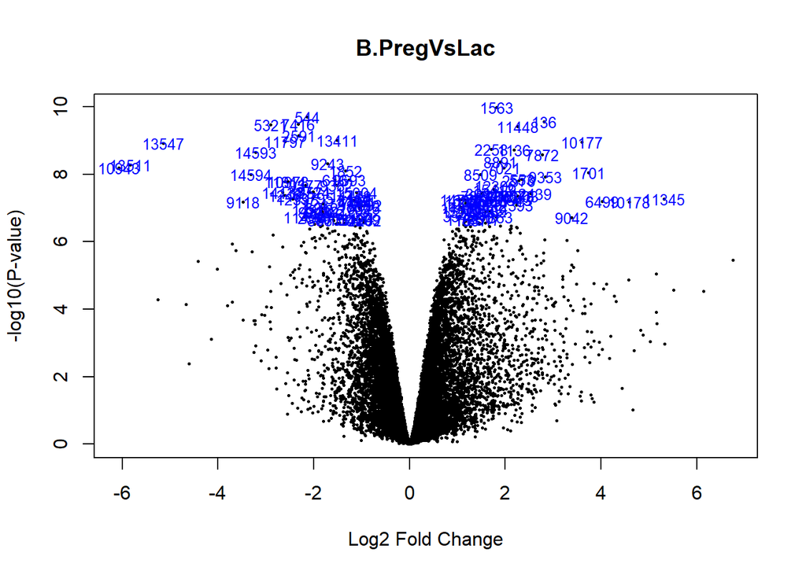

```r
volcanoplot(fit.cont,coef=1,highlight=100,names=fit.cont$genes$SYMBOL, main="B.PregVsLac")
```

### 6.5.2 Heatmap of the top differentially expressed genes

The expression profiles obtained for the top differentially expressed genes can be plotted in a heatmap, with genes (rows) and samples (columns) grouped by similarity.

```r
library("pheatmap")
topGenes <- rownames(toptab_B.PregVsLac)[1:50]
head(topGenes)
```

```
## [1] "24117"  "381290" "78896"  "226101" "16012"  "231830"
```

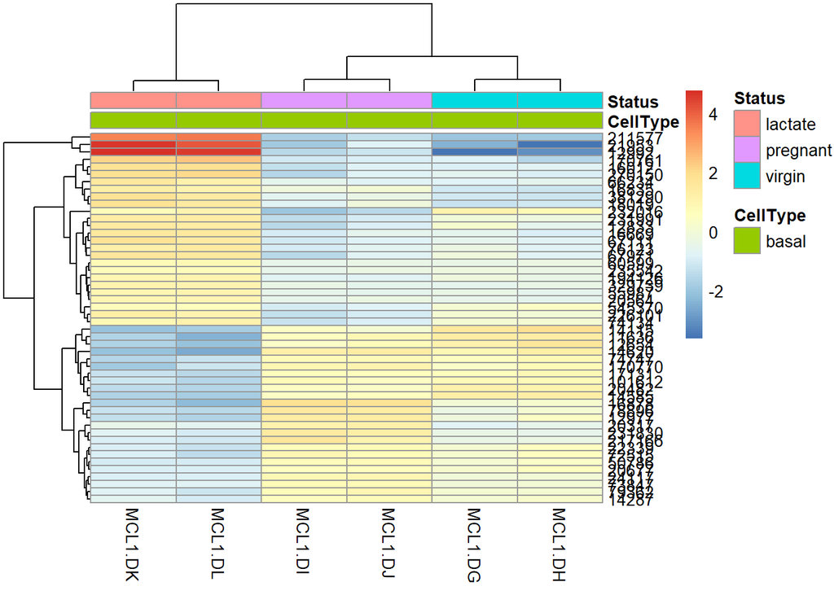

```r
sampleinfo1 <- subset(sampleinfo, CellType=="basal")
mat  <- logcounts_norm[topGenes, sampleinfo1$SampleName]
mat  <- mat - rowMeans(mat)
anno <- sampleinfo1[, c("CellType","Status")]
rownames(anno) <- sampleinfo1$SampleName
pheatmap(mat, annotation_col = anno)
```

**Challenge**

Re-run the code above to test for differences between luminal.pregnant and luminal.lactate groups.